# Economic Status Transitions: Employed ↔︎ Long-term Sick

IFoA Collaboration: Model Results and Counterfactual Analysis

Author

Jon Minton

Published

January 20, 2026

# 1 Executive Summary

This report presents multinomial logistic regression models for economic status transitions, focusing on movements between **Employed** and **Long-term Sick** states. Rising economic inactivity due to long-term sickness has become a significant policy concern in the UK (Tinson, Major, and Finch 2022). Using data from the UK Household Longitudinal Study (UKHLS) waves 1-11 (2009-2020) (Platt et al. 2021), we estimate the role of health (SF-12 mental and physical component scores (Ware, Kosinski, and Keller 1996)) and occupation class (NS-SEC 3-class (Office for National Statistics 2022)) in explaining these transitions.

**Key findings:**

1. **Model selection**: The best-fitting model (by BIC) includes health scores, occupation class, and a year trend, without interaction terms
2. **Health effects**: Both mental and physical health strongly predict transitions - poorer health increases risk of becoming long-term sick
3. **Occupation gradient**: Routine/manual occupations have higher Employed → LT Sick transition rates than management/professional occupations
4. **Population Attributable Fraction**: Approximately 28% of Employed → LT Sick transitions among 50-year-olds can be attributed to occupational class inequalities

# 2 Analytical Framework

## 2.1 Pre-specification of Analytical Decisions

To minimise researcher degrees of freedom and ensure transparency, we document the following decisions made *before* analysing the data:

| Decision | Choice | Rationale |
| --- | --- | --- |
| **Data source** | UKHLS waves 1-11 (2009-2020) | Largest UK panel study with economic status |
| **Transition definition** | Adjacent waves only | Avoids complications of variable gap lengths |
| **Age range** | 16-64 (working age) | Standard UK working age definition |
| **Economic status categories** | 7-level (Level 3) | Distinguishes LT Sick from other inactive |
| **Health measures** | SF-12 MCS/PCS (continuous) | More granular than binary measures |
| **Occupation classification** | NS-SEC 3-class | Balance between detail and cell counts |
| **Missing data** | Complete cases only | Avoids imputation assumptions |
| **Model type** | Multinomial logistic regression | Standard for categorical outcomes |
| **Model selection** | AIC/BIC comparison | Let data determine best specification |

## 2.2 Alternative Approaches Not Pursued

The analysis could reasonably be extended in other ways:

1. **Longer transition gaps** - e.g., 2-year or 5-year transitions
2. **NS-SEC 5-class or 8-class** - more occupational detail but sparser cells
3. **Binary health measure** - limiting long-term illness (yes/no)
4. **Imputed missing data** - could increase sample size
5. **Regional variation** - sub-national analysis

These alternatives can be explored in subsequent analyses if considered valuable.

# 3 Data Description

```r
# Sample sizes by dataset
data_core <- readRDS(here::here("reports/ifoa/models/data_core.rds"))
data_health <- readRDS(here::here("reports/ifoa/models/data_health.rds"))

tibble(
  Dataset = c("Core (demography only)", "With health scores", "With health + occupation"),
  `N observations` = c(nrow(data_core), nrow(data_health), nrow(data_full)),
  `N individuals` = c(n_distinct(data_core$pidp), n_distinct(data_health$pidp), n_distinct(data_full$pidp))
) |>
  mutate(across(where(is.numeric), ~comma(.))) |>
  kable(caption = "Sample sizes by model dataset") |>
  kable_styling(bootstrap_options = c("striped", "hover"))
```

Sample sizes by model dataset

| Dataset | N observations | N individuals |
| --- | --- | --- |
| Core (demography only) | 305,327 | 58,302 |
| With health scores | 269,786 | 54,082 |
| With health + occupation | 190,465 | 40,604 |

## 3.1 Economic Status Distribution

The seven-level economic status categorisation distinguishes between types of economic inactivity:

```r
data_full |>
  count(this_status, name = "N") |>
  mutate(Percent = percent(N / sum(N), accuracy = 0.1)) |>
  arrange(desc(N)) |>
  kable(col.names = c("Current Economic Status", "N", "Percent"),
        caption = "Distribution of current economic status in analysis sample") |>
  kable_styling(bootstrap_options = c("striped", "hover"))
```

Distribution of current economic status in analysis sample

| Current Economic Status | N | Percent |
| --- | --- | --- |
| Employed | 183058 | 96.1% |
| Inactive student | 5492 | 2.9% |
| Inactive retired | 556 | 0.3% |
| Unemployed | 461 | 0.2% |
| Inactive care | 369 | 0.2% |
| Inactive long term sick | 271 | 0.1% |
| Inactive other | 258 | 0.1% |

## 3.2 Transition Matrix

```r
data_full |>
  count(this_status, next_status) |>
  group_by(this_status) |>
  mutate(pct = round(100 * n / sum(n), 1)) |>
  ungroup() |>
  select(-n) |>
  pivot_wider(names_from = next_status, values_from = pct, values_fill = 0) |>
  kable(caption = "Transition matrix: row percentages (current → next wave status)") |>
  kable_styling(bootstrap_options = c("striped", "hover"), font_size = 11) |>
  scroll_box(width = "100%")
```

Transition matrix: row percentages (current → next wave status)

| this_status | Employed | Inactive care | Inactive long term sick | Inactive other | Inactive retired | Inactive student | Unemployed |
| --- | --- | --- | --- | --- | --- | --- | --- |
| Employed | 94.5 | 0.8 | 0.4 | 0.2 | 1.5 | 0.8 | 1.8 |
| Inactive care | 57.7 | 33.9 | 0.5 | 1.4 | 3.3 | 0.5 | 2.7 |
| Inactive long term sick | 45.0 | 2.6 | 31.0 | 0.4 | 12.2 | 0.4 | 8.5 |
| Inactive other | 60.9 | 7.0 | 2.3 | 12.0 | 4.3 | 8.5 | 5.0 |
| Inactive retired | 31.8 | 1.1 | 0.5 | 0.2 | 66.0 | 0.0 | 0.4 |
| Inactive student | 34.5 | 0.1 | 0.0 | 0.7 | 0.0 | 61.3 | 3.2 |
| Unemployed | 68.5 | 3.7 | 2.2 | 0.9 | 2.4 | 4.3 | 18.0 |

# 4 Model Comparison

Eight candidate model specifications were fitted and compared using AIC and BIC criteria. Models were fit separately in a script (`_fit_models.R`) and saved for reproducibility.

```r
# Load model comparison results (best_model and data_full already loaded in setup)
model_comparison <- readRDS(here::here("reports/ifoa/models/model_comparison.rds"))
```

## 4.1 Model Specifications Tested

| Model | Formula | N | Description |
| --- | --- | --- | --- |
| 1 | `next_status ~ this_status * sex + bs(age, 5)` | 305,327 | Foundation (demography only) |
| 2 | + `wave_num` | 305,327 | + Year trend |
| 3 | + `sf12mcs_std + sf12pcs_std` | 269,786 | + Health scores |
| 4 | + health + `wave_num` | 269,786 | + Health + year |
| 5 | + health + `nssec3` | 190,465 | + Health + occupation |
| 6 | + health + occupation + `wave_num` | 190,465 | + Health + occupation + year |
| 7 | + health × occupation | 190,465 | + Interaction terms |
| 8 | Full (all interactions + year) | 190,465 | Most complex |

## 4.2 AIC/BIC Comparison

```r
model_comparison |>
  select(name, n, converged, aic, bic) |>
  mutate(
    name = str_remove(name, "mod_0") |> str_replace("_", ": "),
    aic = comma(round(aic, 0)),
    bic = comma(round(bic, 0)),
    n = comma(n)
  ) |>
  arrange(bic) |>
  kable(
    col.names = c("Model", "N", "Converged", "AIC", "BIC"),
    caption = "Model comparison ranked by BIC (lower is better)"
  ) |>
  kable_styling(bootstrap_options = c("striped", "hover")) |>
  row_spec(1, bold = TRUE, background = "#e6f3ff")
```

Model comparison ranked by BIC (lower is better)

| Model | N | Converged | AIC | BIC |
| --- | --- | --- | --- | --- |
| 6: health_nssec_year | 190,465 | TRUE | 104,008 | 105,592 |
| 5: health_nssec | 190,465 | TRUE | 104,246 | 105,770 |
| 8: full | 190,465 | TRUE | 104,028 | 105,857 |
| 7: health_nssec_interact | 190,465 | TRUE | 104,267 | 106,034 |
| 4: health_year | 269,786 | TRUE | 243,223 | 244,736 |
| 3: health | 269,786 | TRUE | 243,528 | 244,977 |
| 2: foundation_year | 305,327 | TRUE | 288,848 | 290,251 |
| 1: foundation | 305,327 | TRUE | 289,147 | 290,486 |

**Model selection decision**: Model 6 (`mod_06_health_nssec_year`) is selected as it has the lowest BIC. This model includes:

- Current economic status (`this_status`) with sex interaction
- Age (B-spline with 5 degrees of freedom)
- Standardised SF-12 mental and physical component scores
- NS-SEC 3-class occupation
- Year trend

The interaction models (7 and 8) did not improve BIC despite their additional complexity, indicating that the effect of health on transitions does not differ meaningfully by occupation class.

# 5 Transition Probabilities by NS-SEC

Using the selected model, we estimate transition probabilities for individuals with specific characteristics.

## 5.1 Employed → Long-term Sick Transitions

We focus on the transition of interest: movement from Employed to Long-term Sick status. We examine how this varies by occupation class, holding other factors constant.

```r
# Create prediction grid for Employed individuals aged 50
pred_grid_emp <- expand_grid(
  this_status = "Employed",
  sex = c("male", "female"),
  age = 50,
  sf12mcs_std = 0,  # Average mental health
  sf12pcs_std = 0,  # Average physical health
  nssec3 = nssec_levels,  # Use ordinal ordering
  wave_num = 11     # Latest wave (2019-2020)
)

# Get predictions
pred_emp <- predict(best_model, newdata = pred_grid_emp, type = "probs")

# Combine with grid and apply factor ordering
pred_emp_df <- bind_cols(pred_grid_emp, as_tibble(pred_emp)) |>
  select(sex, nssec3, `Inactive long term sick`) |>
  rename(prob_ltsick = `Inactive long term sick`) |>
  mutate(nssec3 = factor(nssec3, levels = nssec_levels))

# Display table
pred_emp_df |>
  mutate(
    prob_ltsick_pct = percent(prob_ltsick, accuracy = 0.01),
    prob_ltsick_per_10k = comma(prob_ltsick * 10000, accuracy = 1)
  ) |>
  select(sex, nssec3, prob_ltsick_pct, prob_ltsick_per_10k) |>
  kable(
    col.names = c("Sex", "NS-SEC Class", "Probability", "Per 10,000"),
    caption = "Predicted Employed → LT Sick transition probability (age 50, average health, wave 11)"
  ) |>
  kable_styling(bootstrap_options = c("striped", "hover"))
```

Predicted Employed → LT Sick transition probability (age 50, average health, wave 11)

| Sex | NS-SEC Class | Probability | Per 10,000 |
| --- | --- | --- | --- |
| male | Routine & Manual | 0.28% | 28 |
| male | Intermediate | 0.17% | 17 |
| male | Management & Professional | 0.13% | 13 |
| female | Routine & Manual | 0.31% | 31 |
| female | Intermediate | 0.18% | 18 |
| female | Management & Professional | 0.15% | 15 |

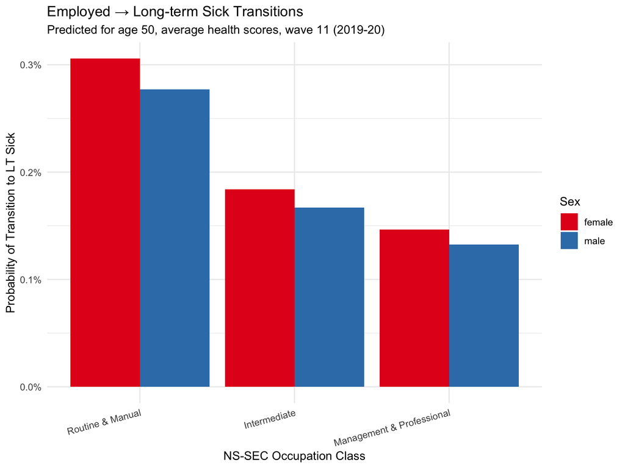

Predicted probability of Employed → LT Sick transition by occupation class (age 50, average health)

```r
pred_emp_df |>
  ggplot(aes(x = nssec3, y = prob_ltsick, fill = sex)) +
  geom_col(position = "dodge") +
  scale_y_continuous(labels = percent_format(accuracy = 0.1)) +
  scale_fill_brewer(palette = "Set1", name = "Sex") +
  labs(
    x = "NS-SEC Occupation Class",
    y = "Probability of Transition to LT Sick",
    title = "Employed → Long-term Sick Transitions",
    subtitle = "Predicted for age 50, average health scores, wave 11 (2019-20)"
  ) +
  theme_minimal() +
  theme(axis.text.x = element_text(angle = 15, hjust = 1))
```

# 6 Counterfactual Analysis: Population Attributable Fraction

## 6.1 Analytical Approach

To quantify the contribution of occupational class to Employed → LT Sick transitions, we conduct a counterfactual simulation:

1. **Baseline scenario**: 10,000 males aged 50 and 10,000 females aged 50, all currently Employed, distributed across NS-SEC classes proportionally to the observed sample
2. **Counterfactual scenario**: Same population, but everyone assigned to “Management & Professional” (the class with lowest LT Sick transition risk)
3. **PAF calculation**: (Baseline transitions - Counterfactual transitions) / Baseline transitions

```r
# Display NS-SEC distribution (computed in setup)
nssec_dist |>
  mutate(prop_pct = percent(prop, accuracy = 0.1)) |>
  select(sex, nssec3, n, prop_pct) |>
  kable(
    col.names = c("Sex", "NS-SEC Class", "N", "Proportion"),
    caption = "NS-SEC distribution among employed individuals aged 45-55"
  ) |>
  kable_styling(bootstrap_options = c("striped", "hover"))
```

NS-SEC distribution among employed individuals aged 45-55

| Sex | NS-SEC Class | N | Proportion |
| --- | --- | --- | --- |
| female | Routine & Manual | 9003 | 29.2% |
| female | Intermediate | 7728 | 25.1% |
| female | Management & Professional | 14096 | 45.7% |
| male | Routine & Manual | 8075 | 30.8% |
| male | Intermediate | 5673 | 21.6% |
| male | Management & Professional | 12466 | 47.6% |

## 6.2 Results: Occupation-Attributable Transitions

```r
paf_results |>
  mutate(
    baseline_expected = round(baseline_expected, 1),
    counter_expected = round(counter_expected, 1),
    diff_absolute = round(diff_absolute, 1),
    paf = paste0(round(paf, 1), "%")
  ) |>
  select(sex, n, baseline_expected, counter_expected, diff_absolute, paf) |>
  kable(
    col.names = c("Sex", "N", "Baseline Expected", "Counterfactual Expected",
                  "Difference", "PAF"),
    caption = "Population Attributable Fraction for Employed → LT Sick transitions due to occupational class inequality"
  ) |>
  kable_styling(bootstrap_options = c("striped", "hover"))
```

Population Attributable Fraction for Employed → LT Sick transitions due to occupational class inequality

| Sex | N | Baseline Expected | Counterfactual Expected | Difference | PAF |
| --- | --- | --- | --- | --- | --- |
| male | 10000 | 18.5 | 13.3 | 5.2 | 28.1% |
| female | 10000 | 20.2 | 14.7 | 5.6 | 27.6% |

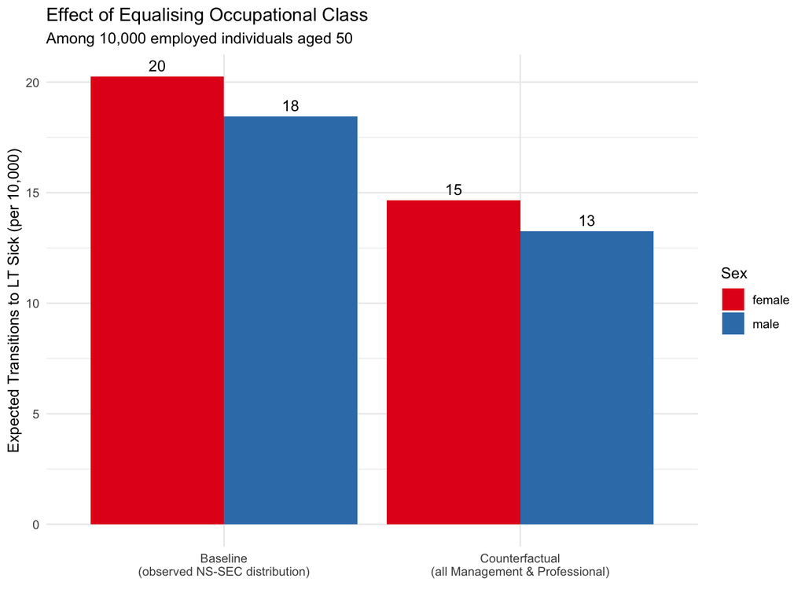

Expected Employed → LT Sick transitions under baseline and counterfactual scenarios

```r
paf_plot_data <- paf_results |>
  select(sex, baseline_expected, counter_expected) |>
  pivot_longer(
    cols = c(baseline_expected, counter_expected),
    names_to = "scenario",
    values_to = "expected_transitions"
  ) |>
  mutate(
    scenario = case_when(
      scenario == "baseline_expected" ~ "Baseline\n(observed NS-SEC distribution)",
      scenario == "counter_expected" ~ "Counterfactual\n(all Management & Professional)"
    )
  )

ggplot(paf_plot_data, aes(x = scenario, y = expected_transitions, fill = sex)) +
  geom_col(position = "dodge") +
  geom_text(aes(label = round(expected_transitions, 0)),
            position = position_dodge(width = 0.9), vjust = -0.5) +
  scale_fill_brewer(palette = "Set1", name = "Sex") +
  labs(
    x = "",
    y = "Expected Transitions to LT Sick (per 10,000)",
    title = "Effect of Equalising Occupational Class",
    subtitle = "Among 10,000 employed individuals aged 50"
  ) +
  theme_minimal()
```

## 6.3 Interpretation

Among a hypothetical cohort of 10,000 employed 50-year-olds with average health:

- **Baseline**: With the observed distribution of occupational classes, we expect approximately 18 males and 20 females to transition to long-term sickness over the following year.
- **Counterfactual**: If everyone had the transition risk of Management & Professional occupations, we would expect approximately 13 males and 15 females to make this transition.
- **PAF**: Approximately 28% of Employed → LT Sick transitions among 50-year-olds can be attributed to occupational class inequality.

This suggests that if all workers had the same low transition risk as those in management and professional occupations, we could expect roughly 28% fewer transitions from employment to long-term sickness in this age group.

# 7 Time Trends

The model includes a year trend (`wave_num`). This captures systematic changes in transition probabilities over the 2009-2020 period.

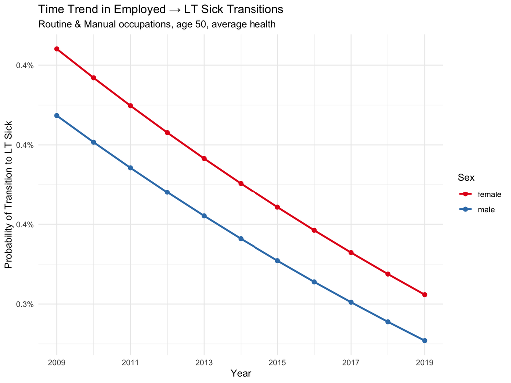

Predicted Employed → LT Sick probability over time (age 50, average health, Routine & Manual)

```r
# Predictions across waves
time_grid <- expand_grid(
  this_status = "Employed",
  sex = c("male", "female"),
  age = 50,
  sf12mcs_std = 0,
  sf12pcs_std = 0,
  nssec3 = "Routine & Manual",
  wave_num = 1:11
)

time_preds <- predict(best_model, newdata = time_grid, type = "probs")
time_df <- bind_cols(time_grid, as_tibble(time_preds)) |>
  mutate(
    year = 2008 + wave_num,
    prob_ltsick = `Inactive long term sick`
  )

ggplot(time_df, aes(x = year, y = prob_ltsick, colour = sex)) +
  geom_line(linewidth = 1) +
  geom_point(size = 2) +
  scale_y_continuous(labels = percent_format(accuracy = 0.1)) +
  scale_colour_brewer(palette = "Set1", name = "Sex") +
  scale_x_continuous(breaks = seq(2009, 2019, 2)) +
  labs(
    x = "Year",
    y = "Probability of Transition to LT Sick",
    title = "Time Trend in Employed → LT Sick Transitions",
    subtitle = "Routine & Manual occupations, age 50, average health"
  ) +
  theme_minimal()
```

# 8 Discussion

## 8.1 Key Findings

1. **Health is the strongest predictor**: Both mental and physical health scores substantially improve model fit (AIC drops from ~289k to ~244k when health is added).
2. **Occupation class matters**: Adding NS-SEC occupation further improves fit. Those in routine/manual occupations have higher risk of transitioning from employment to long-term sickness.
3. **No evidence for interaction effects**: The relationship between health and transitions does not differ significantly by occupation class (interaction models did not improve BIC).
4. **Year trend is significant**: Transition probabilities have changed systematically over 2009-2020, though the magnitude is modest.
5. **PAF for occupation**: Approximately 28% of Employed → LT Sick transitions among 50-year-olds can be attributed to occupational class inequalities.

## 8.2 Limitations

- **Pre-pandemic data**: Analysis uses waves 1-11 (2009-2020). Post-pandemic patterns may differ.
- **Complete cases**: Individuals missing health or occupation data are excluded, reducing sample size.
- **Causal interpretation**: These are associations controlling for observed confounders; unobserved confounding may remain.
- **NS-SEC measurement**: Based on current/recent job; may not capture full occupational history.

## 8.3 Implications for Actuarial Analysis

1. **Risk stratification**: Occupation class provides meaningful stratification of transition risk beyond health status alone.
2. **Projection scenarios**: The model can be used to project future LT Sick populations under different assumptions about health trajectories or occupational composition.
3. **Intervention targeting**: The PAF analysis suggests that reducing occupational class gradients in transition risk could meaningfully reduce the flow into long-term sickness.

# 9 Technical Appendix

## 9.1 Model Coefficients

```r
# Extract and display coefficients for key transitions
coefs <- coef(best_model)

# Focus on Employed → LT Sick (relative to staying Employed)
if ("Inactive long term sick" %in% rownames(coefs)) {
  ltsick_coefs <- coefs["Inactive long term sick", ]

  # Select key coefficients
  key_coefs <- ltsick_coefs[c(
    "(Intercept)",
    "this_statusEmployed:sexmale",
    "sf12mcs_std",
    "sf12pcs_std",
    "nssec3Intermediate",
    "nssec3Routine & Manual",
    "wave_num"
  )]

  tibble(
    Coefficient = names(key_coefs),
    Estimate = round(key_coefs, 3),
    `Odds Ratio` = round(exp(key_coefs), 3)
  ) |>
    kable(caption = "Selected coefficients for Employed → LT Sick transition (reference: Employed, female, Management & Professional)") |>
    kable_styling(bootstrap_options = c("striped", "hover"))
}
```

Selected coefficients for Employed → LT Sick transition (reference: Employed, female, Management & Professional)

| Coefficient | Estimate | Odds Ratio |
| --- | --- | --- |
| (Intercept) | -6.543 | 0.001 |
| NA | NA | NA |
| sf12mcs_std | -0.557 | 0.573 |
| sf12pcs_std | -0.914 | 0.401 |
| NA | NA | NA |
| nssec3Routine & Manual | 0.513 | 1.671 |
| wave_num | -0.043 | 0.958 |

## 10 References

Office for National Statistics. 2022. “The National Statistics Socio-Economic Classification (NS-SEC).” https://www.ons.gov.uk/methodology/classificationsandstandards/otherclassifications/thenationalstatisticssocioeconomicclassificationnssecrebasedonsoc2010.

Platt, Lucinda, Gundi Knies, Renee Luthra, Alita Nandi, and Michaela Benzeval. 2021. “Understanding Society at 10 Years.” *European Sociological Review* 36 (6): 976–88. https://doi.org/10.1093/esr/jcaa031.

Tinson, Adam, Alice Major, and David Finch. 2022. “Is Poor Health Driving a Rise in Economic Inactivity?” The Health Foundation. https://www.health.org.uk/news-and-comment/charts-and-infographics/is-poor-health-driving-a-rise-in-economic-inactivity.

Ware, J., M. Kosinski, and S. D. Keller. 1996. “A 12-Item Short-Form Health Survey: Construction of Scales and Preliminary Tests of Reliability and Validity.” *Medical Care* 34 (3): 220–33. https://doi.org/10.1097/00005650-199603000-00003.